# roahd Package: Robust Analysis of High Dimensional Data

## Outliergram

A method that can be used to detect shape outliers and covariance outliers is the outliergram (see (Arribas-Gil and Romo 2014)), based on the computation of MBD and MEI (see @ref(eq:MBdefuniv) and @ref(eq:MEIdefuniv)) of univariate functional data. Shape outliers are curves that present a different pattern with respect to the rest of the data in terms of their derivatives and covariance outliers are curves generated by a model that is different from the model of the majority of data just in terms of the variance and covariance operator that affects the second order moments of data. Given a set of data $f_1,\ldots, f_n$ in the space $\mathcal{C}(I;\mathbb{R})$ of the continuous functions the following inequality holds:
$$MBD_{\{f_1,...,f_n\}}(f_j) \leq a_0 + a_1
MEI_{\{f_1,...,f_n\}}(f_j) +
a_2 n^2 (MEI_{\{f_1,...,f_n\}}(f_j))^2, \quad j = 1,\cdots, n,
\label{inequality} (\#eq:inequality)$$
where $a_0 = a_2 = -2/(n(n-1))$ and $a_1 = 2(n+1)/(n-1)$. So considering a scatterplot of MBD against multivariate MEI of data, the points lying far from the quadratic boundary @ref(eq:inequality) correspond to shape outliers, and data with very low values of MBD are potential magnitude outliers (see (Arribas-Gil and Romo 2014)). The function `outliergram` displays the outliergram of a univariate functional dataset of class `fData` (see Figure 8) and returns a vector of observation IDs indicating the outlying observations in the dataset.

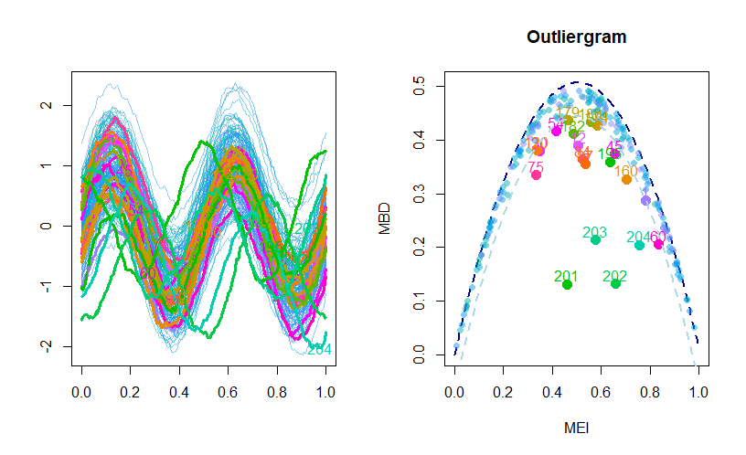

Figure 8: An example of outliergram on simulated univariate functional data

The function `multivariate_outliergram` implements the generalisation of the outliergram to multivariate functional data, following (F. Ieva and Paganoni 2017). Let $\mathbf{X}$ be a stochastic process taking values in the space $C(I;\mathbb{R}^L)$ of continuous functions $\mathbf{f} = (f_1,...,f_L) : I \to \mathbb{R}^L$, where I is a compact interval of $\mathbb{R}$. Let us consider a dataset $F_N$ constituted of $N \in \mathbb{N}$ sample observations of this process, which we indicate by $\mathbf{f}_1,\ldots,\mathbf{f}_N$, $\mathbf{f}_j = (f_{j1},...,f_{jL})$. In (F. Ieva and Paganoni 2017) the following inequality is proved:
$$MBD_{\{\mathbf{f_1},...,\mathbf{f_n}\}}^{J}(\mathbf{f})
\leq a_0 + a_1 MEI_{{\{\mathbf{f_1},...,\mathbf{f_n}\}}}(\mathbf{f}) +
a_2 n^2 (MEI_{{\{\mathbf{f_1},...,\mathbf{f_n}\}}}(\mathbf{f}))^2,
\label{mv_inequality} (\#eq:mv-inequality)$$
where $a_0 = a_2 = -2/(n(n-1))$ and $a_1 = 2(n+1)/(n-1)$, and $MBD_{\{\mathbf{f_1},...,\mathbf{f_n}\}}^{J}(\mathbf{f})$ and $MEI_{{\{\mathbf{f_1},...,\mathbf{f_n}\}}}(\mathbf{f})$ are defined in @ref(eq:MBdefmultiv) and @ref(eq:MEIdefmultiv), respectively.
So the outliergram for multivariate functional data is constructed in analogy with the univariate one and based on the quadratic boundary @ref(eq:mv-inequality). The function `multivariate_outliergram` displays the outliergram of a multivariate functional dataset of class `mfData` (see Figure 9) and returns a vector of observation IDs indicating the outlying observations in the dataset.

```r
    multivariate_outliergram(mfD, Fvalue = 2, shift=TRUE)

    $Fvalue
    2

    $Depth
    [1] 0.0386524565 0.0267086844 0.1297124989 0.0474675556
    [5] 0.0296031652 0.0446769503 0.0353957777 0.0294200492


    $ID_outliers
    [1]  12 18 32 47 70 83 91 96
```

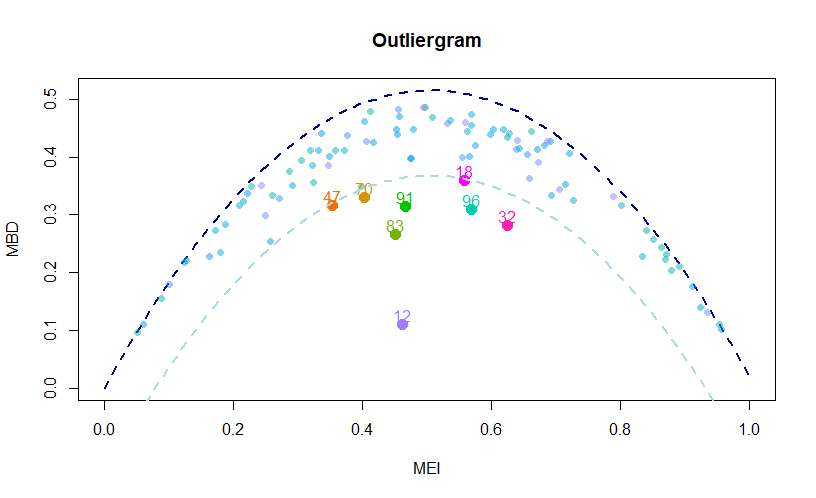

Figure 9: The outliergram of simulated data presented in Figure 4.

# Conclusions

In this paper we have described the implementation in the *roahd* package of several statistical methods that deal with the robust statistical analysis of univariate and multivariate functional data, and some graphical tools mainly aimed at identifying and discarding outliers from a dataset of (potentially multivariate) functional data. The package should simplify the access and use of these strongly nonparametric methods to perform a suitable robust inferential analysis of high dimensional and complex data.

Arribas-Gil, A., and J. Romo. 2014. “Shape Outlier Detection and Visualization for Functional Data: The Outliergram.” *Biostatistics* 15 (4): 603–19.

Claeskens, Gerda, Mia Hubert, Leen Slaets, and Kaveh Vakili. 2014. “Multivariate Functional Halfspace Depth.” *Journal of the American Statistical Association* 109 (505): 411–23.

Dai, Xiongtao, Pantelis Z. Hadjipantelis, Kynghee Han, and Hao Ji. 2018. *Fdapace: Functional Data Analysis and Empirical Dynamics*. https://CRAN.R-project.org/package=fdapace.

Efron, B., and R. J. Tibshirani. 1993. *An Introduction to the Bootstrap*. Chapman & Hall.

Febrero-Bande, Manuel, and Manuel Oviedo de la Fuente. 2012. “Statistical Computing in Functional Data Analysis: The R Package fda.usc.” *Journal of Statistical Software* 51 (4): 1–28.

Ferraty, F., and P. Vieu. 2006. *Nonparametric Functional Data Analysis: Theory and Practice*. New York: Springer.

Horvath, L., and P. Kokoszka. 2012. *Inference for Functional Data with Applications*. New York: Springer.

Ieva, F., and A. M. Paganoni. 2017. “Component-Wise Outlier Detection Methods for Robustifying Multivariate Functional Samples.” *Statistical Papers*.

Ieva, F., A. M. Paganoni, D. Pigoli, and V. Vitelli. 2013. “Multivariate Functional Clustering for the Morphological Analysis of ECG Curves.” *Journal of the Royal Statistical Society: Series C (Applied Statistics)* 62 (3): 401–18.

Ieva, F., F. Palma, and J. Romo. 2018. “Bootstrap-Based Inference for Dependence in Multivariate Functional Data.” MOX Report 30/2018. Politecnico di Milano. https://www.mate.polimi.it/biblioteca/add/qmox/30-2018.pdf.

Ieva, Francesca, and Anna Maria Paganoni. 2013. “Depth Measures for Multivariate Functional Data.” *Communication in Statistics - Theory and Methods* 42 (7): 1265–76.

Kokoszka, P., and M. Reimherr. 2017. *Introduction to Functional Data Analysis*. Chapman & Hall.

Liu, R., J. M. Parelius, and K. Singh. 1999. “Multivariate Analysis by Data Depth: Descriptive Statistics, Graphics and Inference.” *The Annals of Statistics* 27 (3): 783–858.

Liu, R., and K. Singh. 1993. “A Quality Index Based on Data Depth and Multivariate Rank Tests.” *Journal of the American Statistical Association* 88 (421): 252–60.

Lopez-Pintado, S., Y. Sun, and M. G. Genton. 2014. “Simplicial Band Depth for Multivariate Functional Data.” *Advances in Data Analysis and Classification* 8: 321–38.

López-Pintado, S., and J. Romo. 2007. “Depth-Based Inference for Functional Data.” *Computational Statistics & Data Analysis* 51 (10): 4957–68.

———. 2009. “On the Concept of Depth for Functional Data.” *Journal of the American Statistical Association* 104 (486): 718–34.

———. 2011. “A Half-Region Depth for Functional Data.” *Computational Statistics & Data Analysis* 55 (4): 1679–95.

Maronna, Ricardo A, and Ruben H Zamar. 2002. “Robust Estimates of Location and Dispersion for High-Dimensional Datasets.” *Technometrics* 44 (4): 307–17.

Ramsay, J. O., Giles Hooker, and Spencer Graves. 2009. *Functional Data Analysis with r and MATLAB*. 1st ed. Springer Publishing Company, Incorporated.

Ramsay, J. O., and B. W. Silverman. 2002. *Applied Functional Data Analysis: Methods and Case Studies*. New York: Springer.

———. 2005. *Functional Data Analysis*. Second. New York: Springer.

Ramsay, J. O., Hadley Wickham, Spencer Graves, and Giles Hooker. 2014. *Fda: Functional Data Analysis*. https://CRAN.R-project.org/package=fda.

Rasmussen, C. E., and C. Williams. 2006. *Gaussian Processes for Machine Learning*. MIT Press.

Shang, Han Lin, and Rob Hyndman. 2019. *Rainbow: Bagplots, Boxplots and Rainbow Plots for Functional Data*. https://CRAN.R-project.org/package=rainbow.

Sun, Y., and M. G. Genton. 2011. “Functional Boxplots.” *Journal of Computational and Graphical Statistics* 20 (2): 316–34.

———. 2012. “Adjusted Functional Boxplots for Spatio-Temporal Data Visualization and Outlier Detection.” *Environmetrics* 23 (1): 54–64.

Tarabelloni, Nicholas, Ana Arribas-Gil, Francesca Ieva, Anna Maria Paganoni, and Juan Romo. 2017. *Roahd: Robust Analysis of High Dimensional Data*. https://CRAN.R-project.org/package=roahd.

Tarabelloni, N., F. Ieva, R. Biasi, and A. M. Paganoni. 2015. “Use of Depth Measure for Multivariate Functional Data in Disease Prediction: An Application to Electrocardiograph Signals.” *The International Journal of Biostatistics* 11 (2): 189–201.

Tucker, J. Derek. 2017. *Fdasrvf: Elastic Functional Data Analysis*. https://CRAN.R-project.org/package=fdasrvf.

Tuckey, J. 1975. “Mathematics and the Picturing of Data.” In *Proceedings of the International Congress of Mathematicians, Vancouver*, 2:523–31.

Valencia, D., J. Romo, and R. Lillo. 2015a. “A Kendall Correlation Coefficient for Functional Dependence.” http://EconPapers.repec.org/RePEc:cte:wsrepe:ws133228: Universidad Carlos III de Madrid.

———. 2015b. “Spearman Coefficient for Functions.” http://EconPapers.repec.org/RePEc:cte:wsrepe:ws133329: Universidad Carlos III de Madrid.

Zeileis, Achim. 2005. “CRAN Task Views.” *R News* 5 (1): 39–40. https://CRAN.R-project.org/doc/Rnews/.

Zuo, Y., and R. Serfling. 2000. “General Notions of Statistical Depth Function.” *The Annals of Statistics* 28 (2): 461–82.